# 클라우드 / 빅데이터 기말과제

## 201433922 함석윤

## 1. 데이터 설명 및 보기

```python
# 라이브러리 불러오기
import pandas as pd
```

```python
# 파일 경로를 찾고 변수 file_path에 저장
file_path = 'C:/Users/luthi/Desktop/수업자료/빅데이터_클라우드/파이썬 실습데이터/StudentsPerformance_Test.csv'

#read csv() 함수로 데이터프레임 변환
df = pd.read_csv(file_path, encoding='CP949')

# 데이터프레임 보기
df
```

|  | gender | race/ethnicity | parental level of education | lunch | test preparation course | math score | reading score | writing score |
| --- | --- | --- | --- | --- | --- | --- | --- | --- |
| 0 | female | group B | bachelor's degree | standard | none | 72 | 72 | 74 |
| 1 | female | group C | some college | standard | completed | 69 | 90 | 88 |
| 2 | female | group B | master's degree | standard | none | 90 | 95 | 93 |
| 3 | male | group A | associate's degree | free/reduced | none | 47 | 57 | 44 |
| 4 | male | group C | some college | standard | none | 76 | 78 | 75 |
| ... | ... | ... | ... | ... | ... | ... | ... | ... |
| 1001 | female | group D | some college | free/reduced | none | 77 | 120 | 86 |
| 1002 | male | group E | some college | standard | none | 120 | 86 | 86 |
| 1003 | female | NaN | some college | free/reduced | none | 77 | 86 | 86 |
| 1004 | female | group D | some college | standard | completed | 68 | 78 | 77 |
| 1005 | female | group D | some college | free/reduced | NaN | 77 | 86 | 86 |

1006 rows × 8 columns

### 데이터 백업

```python
# 데이터 백업
studentPerformance_copy_backup = df.copy()

# to_csv 메소드를 사용하여 내장 데이터프레임을 csv파일로 저장
# C:\Users\luthi\Desktop\수업자료\빅데이터_클라우드 폴더에 저장
df.to_csv('C:/Users/luthi/Desktop/수업자료/빅데이터_클라우드/studentPerformance_copy_backup.csv')
```

### 데이터 보기

```python
# 데이터프레임의 기본 정보 출력
df.info()
```

```
<class 'pandas.core.frame.DataFrame'>
RangeIndex: 1006 entries, 0 to 1005
Data columns (total 8 columns):
 #   Column                       Non-Null Count  Dtype
---  ------                       --------------  -----
 0   gender                       1005 non-null   object
 1   race/ethnicity               1005 non-null   object
 2   parental level of education  1004 non-null   object
 3   lunch                        1006 non-null   object
 4   test preparation course      1003 non-null   object
 5   math score                   1006 non-null   int64
 6   reading score                1006 non-null   int64
 7   writing score                1006 non-null   int64
dtypes: int64(3), object(5)
memory usage: 63.0+ KB
```

```python
# 열 변수 자료형 확인
df.dtypes
```

```
gender                         object
race/ethnicity                 object
parental level of education    object
lunch                          object
test preparation course        object
math score                      int64
reading score                   int64
writing score                   int64
dtype: object
```

열 변수의 자료형은 정수값(int64) 와 문자열(object)만으로 구성되어있다는 것을 알 수 있습니다.

## Description

### Context

Marks secured by the students

### Content

This data set consists of the marks secured by the students in various subjects.

### Acknowledgements

http://roycekimmons.com/tools/generated_data/exams

### Inspiration

To understand the influence of the parents background, test preparation etc on students performance

데이터 출처 : https://www.kaggle.com/spscientist/students-performance-in-exams

# ---------------------------------------------------------------

**제가 과제로서 사용하는 데이터는 원본 데이터가 아닌 데이터 클린징을 위해 더미 데이터(결측 데이터, 이상 데이터) 를 추가해둔 수정된 데이터프레임입니다.

# ---------------------------------------------------------------

## 2. 데이터 기초 분석 / 탐색

```python
# 파생변수 만들기
df['total'] = df['math score'] + df['reading score'] + df['writing score']

# 정렬
df.sort_values(by=['total'], axis=0, ascending=False)
```

|  | gender | race/ethnicity | parental level of education | lunch | test preparation course | math score | reading score | writing score | total |
| --- | --- | --- | --- | --- | --- | --- | --- | --- | --- |
| 916 | male | group E | bachelor's degree | standard | completed | 100 | 100 | 100 | 300 |
| 458 | female | group E | bachelor's degree | standard | none | 100 | 100 | 100 | 300 |
| 962 | female | group E | associate's degree | standard | none | 100 | 100 | 100 | 300 |
| 114 | female | group E | bachelor's degree | standard | completed | 99 | 100 | 100 | 299 |
| 712 | female | group D | some college | standard | none | 98 | 100 | 99 | 297 |
| ... | ... | ... | ... | ... | ... | ... | ... | ... | ... |
| 76 | male | group E | some high school | standard | none | 30 | 26 | 22 | 78 |
| 327 | male | group A | some college | free/reduced | none | 28 | 23 | 19 | 70 |
| 596 | male | group B | high school | free/reduced | none | 30 | 24 | 15 | 69 |
| 980 | female | group B | high school | free/reduced | none | 8 | 24 | 23 | 55 |
| 59 | female | group C | some high school | free/reduced | none | 0 | 17 | 10 | 27 |

1006 rows × 9 columns

수학, 쓰기, 읽기 점수를 모두 더한 값을 새로 파생된 total 변수로 만들고 그 총점을 기준으로 내림차순 정렬을 하였습니다.

```python
# 인종 별 빈도 분석 (범주형)
df['race/ethnicity'].value_counts()
```

```
group C    320
group D    263
group B    191
group E    141
group A     90
Name: race/ethnicity, dtype: int64
```

- 그룹 C, D, B, E, A 순으로 학생들이 많다는 것을 알 수 있습니다

```python
# 부모님 학력 별 빈도 분석 (범주형)
df['parental level of education'].value_counts()
```

```
some college          232
associate's degree    222
high school           195
some high school      178
bachelor's degree     118
master's degree        59
Name: parental level of education, dtype: int64
```

- 고졸, 대졸 학위를 가진 부모님은 많으나 석사 학위를 가진 부모님은 많이 없으시다는 것을 알 수 있습니다.

```python
# 부모님 학력, 점심 여부 빈도 교차 분석
pd.crosstab(df['race/ethnicity'],df['lunch'])
```

| lunch race/ethnicity | free/reduced | standard |
| --- | --- | --- |
| group A | 36 | 54 |
| group B | 70 | 121 |
| group C | 114 | 206 |
| group D | 96 | 167 |
| group E | 41 | 100 |

```python
#  부모님 학력, 점심 여부 빈도 비율 확인
pd.crosstab(df['lunch'],df['gender']).apply(lambda r: r/len(df),axis=1)
```

| gender lunch | female | male |
| --- | --- | --- |
| free/reduced | 0.190855 | 0.165010 |
| standard | 0.327038 | 0.316103 |

- 점심을 안먹는 학생이 여학생이 더 많다는 것을 알 수 있습니다

### 데이터 구간화

```python
# 총점(0 ~ 300)을 5개의 동일한 길이로 구간화한다.
df1 = pd.cut(df.total,5)
df1

# 5개의 구간의 범주를 그룹함수에 추가해서 각 범주의 그룹별
# 개수(count), 평균(mean), 표준편차(std), 최소값(min), 최대값(max) 을 계산
df2 = df.total.groupby(df1)
df3 = df2.agg(['count', 'mean', 'std', 'min','max'])
df3
```

| total | count | mean | std | min | max |
| --- | --- | --- | --- | --- | --- |
| (26.727, 81.6] | 6 | 62.833333 | 19.467066 | 27 | 78 |
| (81.6, 136.2] | 52 | 118.346154 | 14.833566 | 88 | 136 |
| (136.2, 190.8] | 300 | 166.636667 | 14.566810 | 137 | 190 |
| (190.8, 245.4] | 470 | 216.027660 | 15.204830 | 191 | 245 |
| (245.4, 300.0] | 168 | 264.375000 | 14.755771 | 246 | 300 |

- 총점이 [190.8 ~ 245.4] 구간에 있는 학생들의 비율이 가장 많다는 것을 알 수 있다.
- 총점이 가장 낮은 학생이 27점, 가장 높은 학생이 300점, 만점이라는 것을 알 수 있다.
- 표준 편차를 보면 가장 [136.2 ~ 190.8] 구간에 있는 학생들은 타 구간보다 평균값에 밀집되어 분포되어 있다는 것을 알 수 있다.

### 피봇테이블

```python
# 인종(race/ethnicity) 변수를 행 데이터로 피봇
pd.pivot_table(df,index='gender', columns='race/ethnicity', values='total')
```

| race/ethnicity gender | group A | group B | group C | group D | group E |
| --- | --- | --- | --- | --- | --- |
| female | 195.388889 | 202.807692 | 205.755556 | 214.046875 | 222.044776 |
| male | 184.622642 | 189.000000 | 195.949275 | 200.962406 | 214.436620 |

- 위의 피봇테이블을 활용한 데이터를 보면 그룹E 의 성적이 가장 좋습니다.
- 모든 그룹에서 여학생들이 남학생보다 성적이 좋다는 결과 또한 알 수 있습니다.

### 데이터 그룹 분석

```python
 # 인종 별로 그룹화
df4 = df.groupby(['race/ethnicity'])

df4.get_group('group A')

df.groupby('race/ethnicity').mean()
```

| race/ethnicity | math score | reading score | writing score | total |
| --- | --- | --- | --- | --- |
| group A | 61.629213 | 64.674157 | 62.674157 | 188.977528 |
| group B | 63.526316 | 67.394737 | 65.636842 | 196.557895 |
| group C | 64.440252 | 69.157233 | 67.902516 | 201.500000 |
| group D | 67.325670 | 69.969349 | 70.084291 | 207.379310 |
| group E | 73.840580 | 72.949275 | 71.340580 | 218.130435 |

- 위의 그룹 별 분석을 보면 group A 부터 E 순으로 성적이 좋다는 것을 알 수 있습니다.
- 성적 : group A < group B < group C < group D < group E

```python
df.groupby(['race/ethnicity', 'gender']).mean()
```

| race/ethnicity | gender | math score | reading score | writing score | total |
| --- | --- | --- | --- | --- | --- |
| group A | female | 58.527778 | 69.000000 | 67.861111 | 195.388889 |
|  | male | 63.735849 | 61.735849 | 59.150943 | 184.622642 |
| group B | female | 61.538462 | 71.153846 | 70.115385 | 202.807692 |
|  | male | 65.930233 | 62.848837 | 60.220930 | 189.000000 |
| group C | female | 62.033333 | 71.944444 | 71.777778 | 205.755556 |
|  | male | 67.579710 | 65.521739 | 62.847826 | 195.949275 |
| group D | female | 65.156250 | 73.953125 | 74.937500 | 214.046875 |
|  | male | 69.413534 | 66.135338 | 65.413534 | 200.962406 |
| group E | female | 70.761194 | 75.761194 | 75.522388 | 222.044776 |
|  | male | 76.746479 | 70.295775 | 67.394366 | 214.436620 |

- 남학생은 math score 가 여학생과 비교하여 더 높습니다
- 하지만 나머지 reading score, writing score는 여학생이 더 높습니다.
- 결론적으로 총점 평균은 여학생이 모든 그룹에서 더 높은것을 알 수 있습니다

## 3. 데이터 클린징

### 결측 데이터 처리

```python
# 결측 데이터 갯수 확인
df.isnull().sum()
```

[output not shown]

- 성별, 인종, 부모 학력, 시험 준비코스 열에서 각각 1, 1, 2, 3 총 7개의 결측치를 확인할수 있습니다

```python
# 결측치 제거
df = df.dropna(axis=0) # 결측치 있는 행 제거

df
```

|  | gender | race/ethnicity | parental level of education | lunch | test preparation course | math score | reading score | writing score |
| --- | --- | --- | --- | --- | --- | --- | --- | --- |
| 0 | female | group B | bachelor's degree | standard | none | 72 | 72 | 74 |
| 1 | female | group C | some college | standard | completed | 69 | 90 | 88 |
| 2 | female | group B | master's degree | standard | none | 90 | 95 | 93 |
| 3 | male | group A | associate's degree | free/reduced | none | 47 | 57 | 44 |
| 4 | male | group C | some college | standard | none | 76 | 78 | 75 |
| ... | ... | ... | ... | ... | ... | ... | ... | ... |
| 999 | female | group B | some college | free/reduced | none | 77 | 86 | 86 |
| 1000 | male | group C | some college | standard | none | 77 | 86 | 86 |
| 1001 | female | group D | some college | free/reduced | none | 77 | 120 | 86 |
| 1002 | male | group E | some college | standard | none | 120 | 86 | 86 |
| 1004 | female | group D | some college | standard | completed | 68 | 78 | 77 |

999 rows × 8 columns

- 원래 1006개의 행이 있었는데 결측치 행 제거 후 999개의 행이 있으므로 7개의 결측 데이터가 삭제된 것을 볼 수 있습니다 ###
- 각 컬럼의 평균을 결측값을 대체하는 방법이 있지만 대부분의 결측값이 범주형인 관계로 대체가 아닌 삭제를 통한 방법으로 결측 데이터를 처리했습니다

### 이상 데이터 처리

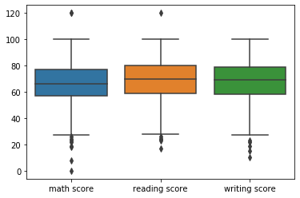

```python
# 이상치 시각화
import seaborn as sns # 시본
sns.boxplot(data = df)
plt.show()
```

- 수학 점수, 읽기 점수에 120 점에 해당하는 이상 데이터를 확인 할 수 있습니다.

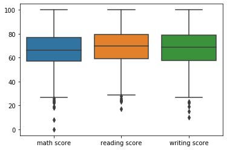

```python
#  math score 100 이하 reading score 100 이하 데이터만 추출
newdf = df[(df["math score"] <= 100) & (df["reading score"] <= 100)]

# 이상치 조정 후 시각화 결과 확인
sns.boxplot(data = newdf)
```

- 100점이 넘는 이상치 데이터가 추출된 것을 확인할 수 있습니다. ###
- 0~ 30점 부분에 위치한 데이터는 현실적으로 받을 수 있는 데이터이기에 이상치 데이터로서 취급하지 않습니다

```python
df = newdf
df
```

|  | gender | race/ethnicity | parental level of education | lunch | test preparation course | math score | reading score | writing score |
| --- | --- | --- | --- | --- | --- | --- | --- | --- |
| 0 | female | group B | bachelor's degree | standard | none | 72 | 72 | 74 |
| 1 | female | group C | some college | standard | completed | 69 | 90 | 88 |
| 2 | female | group B | master's degree | standard | none | 90 | 95 | 93 |
| 3 | male | group A | associate's degree | free/reduced | none | 47 | 57 | 44 |
| 4 | male | group C | some college | standard | none | 76 | 78 | 75 |
| ... | ... | ... | ... | ... | ... | ... | ... | ... |
| 996 | male | group C | high school | free/reduced | none | 62 | 55 | 55 |
| 997 | female | group C | high school | free/reduced | completed | 59 | 71 | 65 |
| 999 | female | group B | some college | free/reduced | none | 77 | 86 | 86 |
| 1000 | male | group C | some college | standard | none | 77 | 86 | 86 |
| 1004 | female | group D | some college | standard | completed | 68 | 78 | 77 |

996 rows × 8 columns

#### 결과적으로 결측치 데이터 7개 삭제, 이상치 데이터 3개가 삭제되어 10개의 행이 삭제되었습니다

## 4. 데이터 시각화

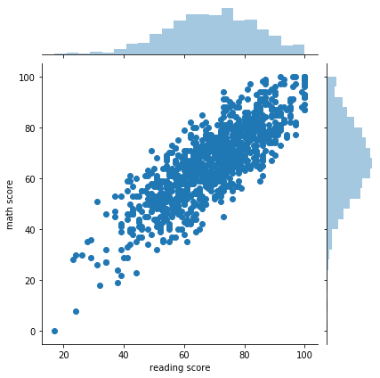

```python
import seaborn as sns # 시본

# 연속형/ 연속형 변수 시각화

sns.jointplot(x = "reading score", y= "math score", data= df, kind='scatter')
```

- reading score 가 높을수록 math score가 높아지는 것을 볼 수 있습니다.
- 대부분 60~ 80점에 분포되어있는 학생이 많습니다.

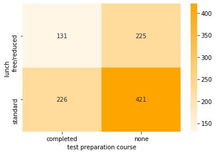

```python
# 범주형 / 범주형 변수 시각화

df_var = df.pivot_table(index="lunch", columns="test preparation course", aggfunc="size")
df_var
sns.heatmap(df_var, cmap=sns.light_palette("orange", as_cmap=True), annot=True, fmt="d")
```

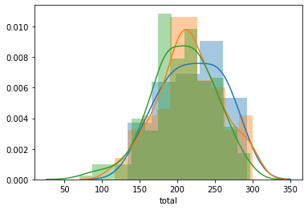

```python
# bachelor's, master's 학위를 가진 부모님의 학생들의 성적 확인

sns.distplot(df['total'].loc[df['parental level of education']=='master\'s degree'])
sns.distplot(df['total'].loc[df['parental level of education']=='bachelor\'s degree'])
sns.distplot(df['total'].loc[df['parental level of education']=='some college'])
```

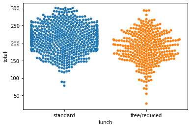

```python
 # 범주형 / 연속형 변수 시각화

    #식사 여부와 성적과의 연관관계는?
sns.swarmplot(x="lunch", y = "total",data= df)
```

- 점심을 먹는 학생들이 대체적으로 성적까지 좋다는 것을 알 수 있습니다

## 5. 통계 또는 머신러닝

## T 분석

### Q1) 식사를 한 학생이 성적이 더 높았다. 유의미한 차이인가?

```python
df['total'].groupby(df['lunch']).mean()
```

```
lunch
free/reduced    187.215084
standard        212.813272
Name: total, dtype: float64
```

```python
lunchgroup = df.groupby('lunch')

no = lunchgroup.get_group('free/reduced')
yes = lunchgroup.get_group('standard')
no_subset = no[['lunch', 'total']]
yes_subset = yes[['lunch', 'total']]
print(no_subset)
print(yes_subset)
```

```
             lunch  total
3     free/reduced    148
7     free/reduced    122
8     free/reduced    195
9     free/reduced    148
17    free/reduced     78
...            ...    ...
997   free/reduced    195
999   free/reduced    249
1001  free/reduced    283
1003  free/reduced    249
1005  free/reduced    249

[358 rows x 2 columns]
         lunch  total
0     standard    218
1     standard    247
2     standard    278
4     standard    229
5     standard    232
...        ...    ...
995   standard    282
998   standard    292
1000  standard    249
1002  standard    292
1004  standard    223

[648 rows x 2 columns]
```

```python
from scipy import stats

tTestResult = stats.ttest_ind(no_subset['total'],yes_subset['total'])
print(tTestResult)

tTestResultDiffVar = stats.ttest_ind(no_subset['total'],yes_subset['total'], equal_var=False)
print(tTestResultDiffVar)
```

```
Ttest_indResult(statistic=-9.433710068870989, pvalue=2.6599485539658588e-20)
Ttest_indResult(statistic=-9.176965319073348, pvalue=5.252595348896812e-19)
```

- p-value 값이 5.2 x (1/10)의 19승, 2.6 x (1/10)의 20승이므로 0에 매우 가까운 값이므로 점심 식사에 의해 유의미한 차이가 생긴다는 의미이다.

### Q2) 시험준비 코스를 밟고 있는 학생이 성적이 높았다. 유의미한 차이인가?

```python
df['total'].groupby(df['test preparation course']).mean()
```

```
test preparation course
completed    217.829132
none         195.662539
Name: total, dtype: float64
```

```python
testgroup = df.groupby('test preparation course')

none = testgroup.get_group('none')
completed = testgroup.get_group('completed')
none_subset = none[['test preparation course', 'total']]
completed_subset = completed[['test preparation course', 'total']]

tTestResult = stats.ttest_ind(none_subset['total'],completed_subset['total'])
print(tTestResult)

tTestResultDiffVar = stats.ttest_ind(none_subset['total'],completed_subset['total'], equal_var=False)
print(tTestResultDiffVar)
```

```
Ttest_indResult(statistic=-8.076333718006873, pvalue=1.9071096554429635e-15)
Ttest_indResult(statistic=-8.30444241803584, pvalue=4.29192995414126e-16)
```

- p-value 값이 1.9 x (1/10)의 15승, 4.2 x (1/10)의 16승이므로 0에 매우 가까운 값이므로 시험 준비 코스를 밟고 있는것에 의해 유의미한 차이가 생긴다는 의미이다.

## 상관분석 / 회귀분석

```python
import numpy as np
import matplotlib.pylab as plt
```

```python
# 상관계수 확인
corr = df.corr()
corr
```

|  | math score | reading score | writing score | total |
| --- | --- | --- | --- | --- |
| math score | 1.000000 | 0.812031 | 0.800170 | 0.917489 |
| reading score | 0.812031 | 1.000000 | 0.952603 | 0.968696 |
| writing score | 0.800170 | 0.952603 | 1.000000 | 0.965041 |
| total | 0.917489 | 0.968696 | 0.965041 | 1.000000 |

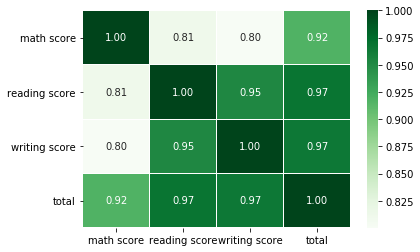

```python
# 상관도 시각화
sns.heatmap(data = df.corr(), annot=True, fmt = '.2f', linewidths= .10, cmap='Greens')
```

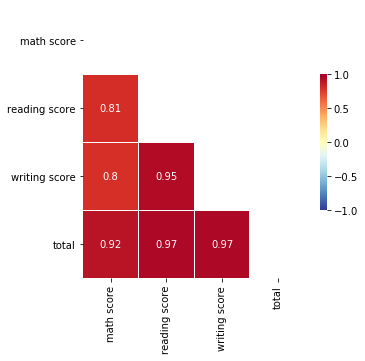

```python
df5 = df.corr()

# 그림 사이즈 지정
fig, ax = plt.subplots(figsize=(5,5))

# 삼각형 마스크를 작성합니다.
mask = np.zeros_like(df5, dtype = np.bool)
mask[np.triu_indices_from(mask)] = True

# 히트맵 그리기
sns.heatmap(df5, cmap = 'RdYlBu_r',
           annot = True,   # 실제 값을 표시한다
           mask=mask,        # 표시하지 않을 마스크 부분을 지정
           linewidths=.5,     # 경계면 실선으로 구분하기
           cbar_kws={"shrink":.5},  # 컬러바 크기 절반으로 줄이기
           vmin = -1, vmax = 1)
```

- 본 데이터프레임의 연속형 데이터 변수가 4가지이며 그 4가지는 서로 연관이 있기에 저렇게 표현이 됩니다

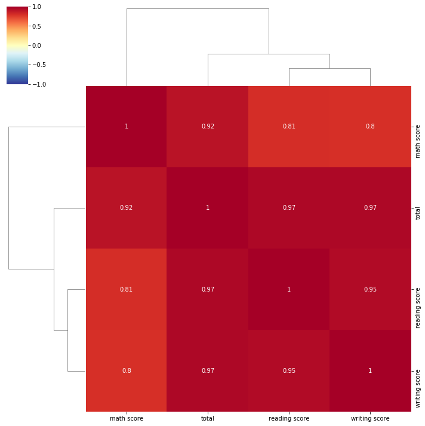

```python
sns.clustermap(df5, annot = True, cmap = 'RdYlBu_r', vmin = -1, vmax = 1)
```

- 회귀 분석 하기전 컬럼 명을
- reading score -> reading
- writing score -> writing 으로 변경하겠습니다. 중간에 띄어쓰기 때문에 인식이 안됩니다.

```python
newdf.columns=['gender','race/ethnicity','parental level of education','lunch',
              'test preparation course', 'math','reading','writing','total']
newdf
```

|  | gender | race/ethnicity | parental level of education | lunch | test preparation course | math | reading | writing | total |
| --- | --- | --- | --- | --- | --- | --- | --- | --- | --- |
| 0 | female | group B | bachelor's degree | standard | none | 72 | 72 | 74 | 218 |
| 1 | female | group C | some college | standard | completed | 69 | 90 | 88 | 247 |
| 2 | female | group B | master's degree | standard | none | 90 | 95 | 93 | 278 |
| 3 | male | group A | associate's degree | free/reduced | none | 47 | 57 | 44 | 148 |
| 4 | male | group C | some college | standard | none | 76 | 78 | 75 | 229 |
| ... | ... | ... | ... | ... | ... | ... | ... | ... | ... |
| 996 | male | group C | high school | free/reduced | none | 62 | 55 | 55 | 172 |
| 997 | female | group C | high school | free/reduced | completed | 59 | 71 | 65 | 195 |
| 999 | female | group B | some college | free/reduced | none | 77 | 86 | 86 | 249 |
| 1000 | male | group C | some college | standard | none | 77 | 86 | 86 | 249 |
| 1004 | female | group D | some college | standard | completed | 68 | 78 | 77 | 223 |

996 rows × 9 columns

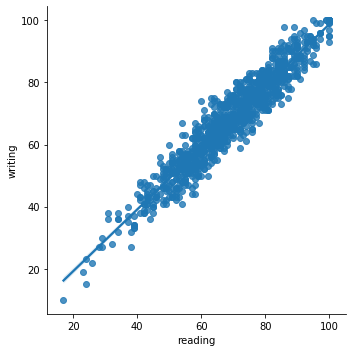

```python
sns.lmplot(x = 'reading', y='writing', data = newdf)
```

```python
# 회귀 분석을 위해 종속(Y = 쓰기 점수), 독립(X = 읽기 점수)하는 모델을 만듭니다.
# 읽기 점수를 알면 쓰기 점수를 예상 할 수 있습니다
# 단순 선형회귀 모형
import statsmodels.api as sm
lin_reg = sm.OLS.from_formula("reading ~ writing", newdf).fit()
lin_reg.summary()
```

OLS Regression Results

| Dep. Variable: | reading | R-squared: | 0.911 |
| --- | --- | --- | --- |
| Model: | OLS | Adj. R-squared: | 0.911 |
| Method: | Least Squares | F-statistic: | 1.019e+04 |
| Date: | Sun, 05 Jul 2020 | Prob (F-statistic): | 0.00 |
| Time: | 23:25:51 | Log-Likelihood: | -2877.5 |
| No. Observations: | 996 | AIC: | 5759. |
| Df Residuals: | 994 | BIC: | 5769. |
| Df Model: | 1 |  |  |
| Covariance Type: | nonrobust |  |  |

|  | coef | std err | t | P>\|t\| | [0.025 | 0.975] |
| --- | --- | --- | --- | --- | --- | --- |
| Intercept | 6.7662 | 0.633 | 10.687 | 0.000 | 5.524 | 8.009 |
| writing | 0.9168 | 0.009 | 100.969 | 0.000 | 0.899 | 0.935 |

| Omnibus: | 3.004 | Durbin-Watson: | 1.968 |
| --- | --- | --- | --- |
| Prob(Omnibus): | 0.223 | Jarque-Bera (JB): | 3.076 |
| Skew: | -0.126 | Prob(JB): | 0.215 |
| Kurtosis: | 2.898 | Cond. No. | 320. |

Warnings:  
[1] Standard Errors assume that the covariance matrix of the errors is correctly specified.

## 회귀분석 평가

- R - squared 값 : 0.911 이므로 적합성이 91.1%을 보장하므로 사용하기에 적합한 모델이라고 볼 수 있다. #####
- coef(coefficient, 계수)를 보면, intercept은 6.7662, writing은 0.9168 입니다. 이것을 선형 회귀분석 모델에 대입하면 '읽기 = 0.9168 * 쓰기 + 6.7662' 의 예측 모형식을 만들 수 있습니다. #####
- P > |t|(유의확률) 값을 보면 0 으로써, 쓰기 점수는 읽기 점수에 유의미하게 영향을 미친다고 알 수 있습니다. #####
- Durbin-Watson의 값은 1.968 입니다. 이 값은 잔차의 독립성을 확인할 수 있는 수치입니다. 1.5~ 2.5 사이에 해당하는 값이므로 독립으로 판단하며 회귀모형이 적합하다는 것으로 의미합니다. #####
- No.observations 는 996 이므로 996개의 데이터쌍을 가지고 회귀분석을 했다는 의미입니다.

## 6. 결론 및 본인 차별화 포인트

#### 제가 찾은 데이터셋으로 어떤 환경을 가진 학생이 성적이 좋을까 라는

#### 궁금증을 기준으로 데이터를 분석해보았습니다.

### 결론

#### 총 성적 기준

- 이 데이터셋을 기준으로 여학생이 남학생 공부를 잘한다. ####
- 남학생들은 여학생보다 수학 점수가 대체적으로 높다. ####
- 어느 한 과목을 잘할수록 다른 과목도 대체적으로 잘한다. ####
- 부모님의 최종 학력이 높을수록 학생도 성적이 높다. ####
- 점심을 먹은 학생들이 성적이 더 높다. ####
- 시험 준비 코스를 밟고 있는 학생들이 성적이 더 높다. #### ======================================================== #### 그 외
- 인종 별로 그룹을 나누었다고 했지만 A < B < C < D < E 그룹 순으로 성적이 높다 ####
- 상관/회귀 분석을 통해 쓰기 점수는 읽기 점수에 유의미하게 영향을 미치며 적합성이 91.1%을 보장하므로 사용하기에 적합한 모델이다.